# Quality Control

hiox-tech

2026-08-06

# 1 Analysis Objectives

Quality control (QC) determines whether a measurement system is in control by periodically measuring quality-control materials and monitoring whether the results deviate from target values. `ivdtools` provides Levey–Jennings charts with Westgard multi-rule evaluation (`qc_chart()`), grouped monitoring in lot-change/group-change scenarios, and the Youden plot for two-level QC (`youden_plot()`).

This document demonstrates: obtaining and understanding the Westgard rules, whether daily QC results exceed the limits, how to evaluate grouping correctly when a reagent lot changes, and the Youden plot for two-level QC. The example data are deterministic teaching data; **the Westgard rule combination and allowable limits should be pre-determined according to the laboratory’s risk-management strategy and protocol**.

```r
library(ivdtools)
library(readr)
```

# 2 Overview of Functions

| Function | Main purpose | Key input or output |
| --- | --- | --- |
| `list_westgard()` | View Westgard rule names and meanings | `brief=TRUE` returns only the rule vector |
| `qc_chart()` | Levey–Jennings chart + rule judgment | `rules`, `mean`/`sd`, `group`, `run` |
| `youden_plot()` | Youden plot for two-level QC | two sample columns, target means/SDs |

# 3 Example 1: Obtaining Rules and Daily QC

## 3.1 Viewing the Westgard Rules

```r
list_westgard()
```

```
#>
#> Westgard QC Rules
#>   --------------------------------------------------
#>   1-2s    1 point exceeds +/-2s (warning)
#>   1-3s    1 point exceeds +/-3s (out of control)
#>   2-2s    2 consecutive points exceed +/-2s (same side)
#>   R-4s    2 consecutive points differ by at least 4s
#>   4-1s    4 consecutive points exceed +/-1s (same side)
#>   8x      8 consecutive points on same side of mean
#>   10x     10 consecutive points on same side of mean
#>   --------------------------------------------------
```

## 3.2 Reading Daily QC Data

```r
qc_daily <- read_csv("./data/qc-daily.csv", show_col_types = FALSE)
qc_daily <- as.data.frame(qc_daily)
head(qc_daily)
```

|  | run | value |
| --- | --- | --- |
| 1 | 1 | 103.24 |
| 2 | 2 | 103.06 |
| 3 | 3 | 94.52 |
| 4 | 4 | 99.51 |
| 5 | 5 | 99.14 |
| 6 | 6 | 95.62 |

The data are daily QC results with target mean = 100, SD = 3, for a total of 30 run points.

## 3.3 Running Quality Judgments

```r
qc <- qc_chart(
  qc_daily,
  value = "value",
  rules = "1-2s,1-3s,2-2s,R-4s,4-1s,10x",
  mean = 100,
  sd = 3,
  run = "run"
)
print(qc)
```

```
#>
#> QC Control Chart
#>   Value column:    value
#>   Mean (target):   100.0000
#>   SD (target):     3.0000
#>   N (total):       30  |  Complete: 30  |  Missing: 0
#>   Rules applied:   1-2s, 1-3s, 2-2s, R-4s, 4-1s, 10x
#>
#>   Violations:
#>   --------------------------------------------------
#>     1-2s  : points 15, 23
#>     1-3s  : points 15
#>   -> 2 violation(s): 1 warning(s), 1 out of control
```

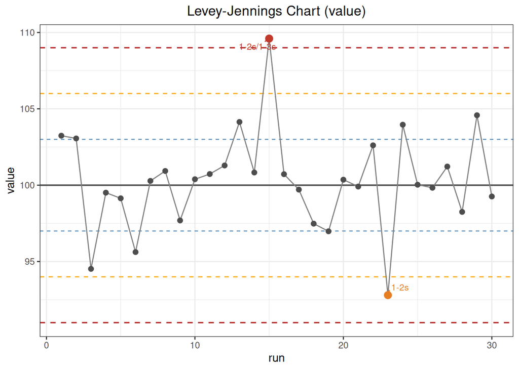

```r
plot(qc)
```

`qc_chart()` records the points violating each rule in `$violations`:

```r
qc$violations
```

```
#> $`1-2s`
#> [1] 15 23
#>
#> $`1-3s`
#> [1] 15
#>
#> $`2-2s`
#> integer(0)
#>
#> $`R-4s`
#> integer(0)
#>
#> $`4-1s`
#> integer(0)
#>
#> $`10x`
#> integer(0)
```

In this example, point 15 exceeds +3s (triggering `1-3s` and `1-2s`, judged out of control), and point 23 falls below −2s (triggering `1-2s`, judged a warning). `n_warn` and `n_oc` give the warning and out-of-control point counts, respectively.

> **Parameter notes:** The `rules` of `qc_chart()` is a comma-separated rule string; `mean`/`sd` are the target values (when not given, they are estimated from the data, but monitored QC should use target values from the instructions). `run` specifies the run-order column, and `group` specifies the grouping column (see Example 2).

# 4 Example 2: Grouped Evaluation on Reagent Lot Change

## 4.1 Reading Data

In the data, the first 10 points are lot L1, the middle 10 are lot L2 (with an overall shift), and the last 10 are lot L3:

```r
qc_lot <- read_csv("./data/qc-lot-change.csv", show_col_types = FALSE)
qc_lot <- as.data.frame(qc_lot)
table(qc_lot$lot)
```

```
#>
#> L1 L2 L3
#> 10 10 10
```

## 4.2 Grouping the Whole Sequence

Use `group = "lot"` for plotting; the Westgard rules are still judged on the **entire sequence**:

```r
qc_lot_all <- qc_chart(
  qc_lot,
  value = "value",
  mean = 100,
  sd = 3,
  run = "run",
  group = "lot"
)
qc_lot_all$n_oc
```

```
#> [1] 0
```

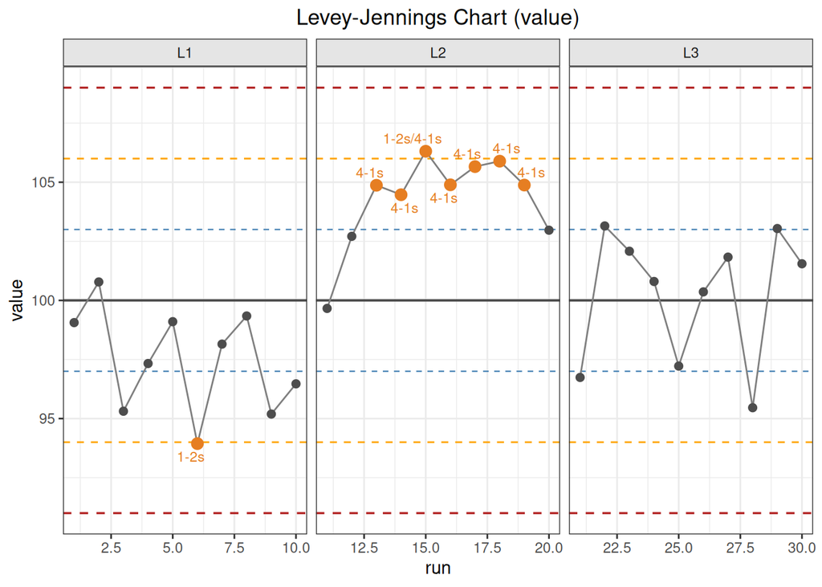

```r
plot(qc_lot_all)
```

Although the plot is faceted by lot, the rules are computed on the entire sequence, so observe the systematic shift caused by the lot change.

# 5 Example 3: Youden Plot for Two-Level QC

## 5.1 Reading Data

The Youden plot uses the results of two quality-control materials at different concentrations (levels) in the same run (wide-table format, one column per level):

```r
youden_dat <- read_csv("./data/qc-youden.csv", show_col_types = FALSE)
youden_dat <- as.data.frame(youden_dat)
head(youden_dat)
```

|  | run | low | high |
| --- | --- | --- | --- |
| 1 | 1 | 77.86 | 209.36 |
| 2 | 2 | 82.19 | 207.10 |
| 3 | 3 | 75.50 | 189.00 |
| 4 | 4 | 80.40 | 195.36 |
| 5 | 5 | 80.64 | 198.23 |
| 6 | 6 | 78.22 | 200.14 |

## 5.2 Drawing the Youden Plot

```r
yd <- youden_plot(
  youden_dat,
  sample1 = "low",
  sample2 = "high",
  mean1 = 80,
  mean2 = 200,
  sd1 = 2,
  sd2 = 5
)
print(yd)
```

```
#>
#> Youden Plot
#>   Sample 1 (low):
#>     Mean:   80.0000
#>     SD:     2.0000
#>   Sample 2 (high):
#>     Mean:   200.0000
#>     SD:     5.0000
#>   Correlation: 0.5428
#>   N (total):   30  |  Complete: 30  |  Missing: 0
#>   Points outside +/-2SD: 3  (rows: 3, 17, 19)
```

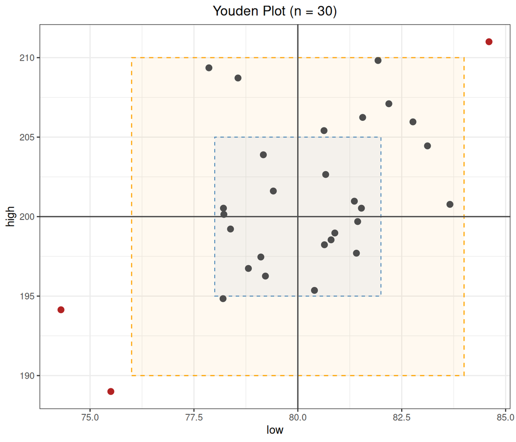

```r
plot(yd)
```

```r
yd$outside_rows
```

```
#> [1]  3 17 19
```

> **Parameter notes:** The `sample1`/`sample2` of `youden_plot()` are the numeric columns of the two levels; `mean1`/`mean2`/`sd1`/`sd2` are the target values (when not given, they are estimated from the data). `$n_outside` and `$outside_rows` give the points outside the rectangle.

# 6 Key Points for Interpreting Results

1. **Target-value source**: The target mean and SD of the QC chart should come from the instructions or validation data, not be estimated on the fly from the data.
2. **Rule combination**: The Westgard rule combination and the disposition process for judging out of control should be pre-specified in the protocol and re-evaluated with the risk.
3. **Two-level complementarity**: The Youden plot looks at the joint performance of both levels simultaneously, identifying signs of systematic and random error.
4. **Out-of-control disposition**: After detecting an out-of-control point, stop reporting, investigate the cause, re-validate and recall if necessary, and record the complete disposition chain.
5. **Statistics ≠ release**: QC judgment is one basis for the release decision; the final decision should comply with the laboratory’s quality-system requirements.